# Assignment 6 RNAseq PArt 2

Student Name: Koki Sasagawa Student ID: 999054646

Insert your answers below. Knit this file and submit the .Rmd and .html when you are done. Open an issue indicating that the assignment is ready to be graded.

After finding differentially expressed genes, we want to find their specific functions.

Download the file by typing the following in command line

```
wget http://www.g3journal.org/content/suppl/2014/08/12/g3.114.012526.DC1/FileS9.txt

#move it into Brapa_reference folder
mv ~/Files9.txt ~/Assignments/Assignment_6_Sasagawa.Koki/Brapa_reference
```

**Exercise 1**:  
**a.** Use `merge()` to add gene descriptions for the genes found to be regulated by the DP treatment. Output a table of the top 10 genes that includes the output from edgeR and the descriptions. __Important: Pay attention to the “sort=”" argument to `merge()`. Should it be TRUE or FALSE?

```r
#read in files
gene_annotation <- read.delim("./Brapa_reference/FileS9.txt", header = FALSE)

DEgenes.trt <- read.csv("./DEgenes.trt.csv", header = TRUE)

#Check
head(gene_annotation)
```

```
##          V1                                                  V2
## 1 Bra000001                    DNAse I-like superfamily protein
## 2 Bra000002 nodulin MtN21 /EamA-like transporter family protein
## 3 Bra000003                                 No annotation found
## 4 Bra000004                                 No annotation found
## 5 Bra000005                                    ARF-GAP domain 7
## 6 Bra000006                         Histone superfamily protein
```

```r
head(DEgenes.trt)
```

```
##           X     logFC   logCPM        LR       PValue          FDR
## 1 Bra028803 -5.043456 3.514222 132.19854 1.353794e-30 3.253709e-26
## 2 Bra019324  4.809736 2.209125  76.43637 2.274239e-18 2.732953e-14
## 3 Bra034565  4.081287 2.159299  68.93415 1.018066e-16 8.156067e-13
## 4 Bra025587  4.190919 3.298713  55.04401 1.178608e-13 7.081667e-10
## 5 Bra029946  2.280844 5.364465  47.80173 4.715747e-12 1.898675e-08
## 6 Bra026156  1.764672 6.467797  47.50653 5.482100e-12 1.898675e-08
```

```r
#Add column names to gene_annotation
colnames(gene_annotation) <- c("X", "GO")

#Merge the gene annotation files with the genes found to be regulated by the DP treatment
#We do not want to use sort as the data frame has the genes in order from most differentially expressed.
DEgenes.trt.anno <- merge(DEgenes.trt, gene_annotation, by="X", sort=FALSE)

#Rename Columns
colnames(DEgenes.trt.anno)[1] <- "geneID"
colnames(DEgenes.trt.anno)[7] <- "GO_annotation"

#Display Top 10 genes
head(DEgenes.trt.anno, n = 10)
```

```
##       geneID     logFC   logCPM        LR       PValue          FDR
## 1  Bra028803 -5.043456 3.514222 132.19854 1.353794e-30 3.253709e-26
## 2  Bra019324  4.809736 2.209125  76.43637 2.274239e-18 2.732953e-14
## 3  Bra034565  4.081287 2.159299  68.93415 1.018066e-16 8.156067e-13
## 4  Bra025587  4.190919 3.298713  55.04401 1.178608e-13 7.081667e-10
## 5  Bra029946  2.280844 5.364465  47.80173 4.715747e-12 1.898675e-08
## 6  Bra026156  1.764672 6.467797  47.50653 5.482100e-12 1.898675e-08
## 7  Bra030161  2.846792 5.105622  47.48949 5.529969e-12 1.898675e-08
## 8  Bra037739  2.041482 4.539958  47.09441 6.764831e-12 2.032324e-08
## 9  Bra016050  5.119232 1.755334  46.01184 1.175405e-11 3.138854e-08
## 10 Bra029042  3.496552 1.240656  45.59897 1.451181e-11 3.487769e-08
##                                                  GO_annotation
## 1                       Phosphoglycerate mutase family protein
## 2           cysteine-rich RLK (RECEPTOR-like protein kinase) 5
## 3                                        myb domain protein 69
## 4                        Protein of unknown function (DUF1645)
## 5                     Cysteine proteinases superfamily protein
## 6                                pleiotropic drug resistance 7
## 7             Leucine-rich repeat transmembrane protein kinase
## 8  Plant invertase/pectin methylesterase inhibitor superfamily
## 9                           Protein kinase superfamily protein
## 10                                         No annotation found
```

**b.** Repeat this for genes with a genotype x trt interaction.

```r
#read in files
DEgenes.gt.trt <- read.csv("./DEgenes.gt.trt.csv", header = TRUE)

#Check
head(DEgenes.gt.trt)
```

```
##           X     logFC   logCPM        LR       PValue          FDR
## 1 Bra010821  6.657169 6.039363 153.40585 3.123026e-35 7.505881e-31
## 2 Bra033034 -4.639885 6.613817  71.41018 2.901710e-17 3.486985e-13
## 3 Bra035334 -4.142522 4.672753  68.17554 1.495697e-16 1.198253e-12
## 4 Bra003598 -4.893671 3.899406  54.12693 1.879472e-13 1.129281e-09
## 5 Bra016182  7.714135 6.327919  49.74724 1.748837e-12 8.406307e-09
## 6 Bra009406  6.199655 6.591944  47.38590 5.830042e-12 2.335321e-08
```

```r
#Merge the gene annotation files with the differentially expressed genes
DEgenes.gt.trt.anno <- merge(DEgenes.gt.trt, gene_annotation, by="X", sort=FALSE)

#Rename Columns
colnames(DEgenes.gt.trt.anno)[1] <- "geneID"
colnames(DEgenes.gt.trt.anno)[7] <- "GO_annotation"

#Display Top 10 genes
head(DEgenes.gt.trt.anno, n = 10)
```

```
##       geneID     logFC   logCPM        LR       PValue          FDR
## 1  Bra010821  6.657169 6.039363 153.40585 3.123026e-35 7.505881e-31
## 2  Bra033034 -4.639885 6.613817  71.41018 2.901710e-17 3.486985e-13
## 3  Bra035334 -4.142522 4.672753  68.17554 1.495697e-16 1.198253e-12
## 4  Bra003598 -4.893671 3.899406  54.12693 1.879472e-13 1.129281e-09
## 5  Bra016182  7.714135 6.327919  49.74724 1.748837e-12 8.406307e-09
## 6  Bra009406  6.199655 6.591944  47.38590 5.830042e-12 2.335321e-08
## 7  Bra033856 -3.234820 5.719983  47.05088 6.916756e-12 2.374819e-08
## 8  Bra013164  4.097985 9.328875  46.65830 8.450846e-12 2.454159e-08
## 9  Bra011196  5.017733 3.348450  46.49397 9.190076e-12 2.454159e-08
## 10 Bra041036 -3.280732 7.165359  45.87903 1.257854e-11 3.023127e-08
##                                                  GO_annotation
## 1           GDSL-like Lipase/Acylhydrolase superfamily protein
## 2                                  Nodulin MtN3 family protein
## 3                   HXXXD-type acyl-transferase family protein
## 4                        Wall-associated kinase family protein
## 5                                          MLP-like protein 28
## 6  Plant invertase/pectin methylesterase inhibitor superfamily
## 7                                      pinoresinol reductase 1
## 8                  xyloglucan endotransglucosylase/hydrolase 4
## 9                                         glycine-rich protein
## 10                           S-adenosylmethionine synthetase 1
```

**Exercise 2**:  
There might be an enrichment for cell wall related genes. See if there is a statistical over-representation of particular Gene Ontology (GO) terms in this set of genes. Is the prevalence of a term in our gene set of interest higher than its prevalence in the rest of the genome?

Download GO annotation and gene length for B.rapa, and Expressed genes

```
#GO terms
wget http://www.g3journal.org/content/suppl/2014/08/12/g3.114.012526.DC1/FileS11.txt
#Gene Length
wget http://jnmaloof.github.io/BIS180L_web/data/Brapa_CDS_lengths.txt
#Expressed genes
wget http://jnmaloof.github.io/BIS180L_web/data/internode_expressed_genes.txt
```

Get the Data

```r
library(goseq)
go.terms <- read.delim("./Brapa_reference/FileS11.txt",header=FALSE,as.is=TRUE)
head(go.terms)
```

```
##          V1
## 1 Bra002000
## 2 Bra001201
## 3 Bra001122
## 4 Bra001115
## 5 Bra001108
## 6 Bra001050
##                                                                             V2
## 1                                                                   GO:0005488
## 2 GO:0000160,GO:0009927,GO:0000155,GO:0018106,GO:0005524,GO:0004740,GO:0005739
## 3                                  GO:0050832,GO:0016023,GO:0008061,GO:0042742
## 4 GO:0009825,GO:0001578,GO:0055028,GO:0007163,GO:0010031,GO:0010015,GO:0010091
## 5                                                        GO:0000166,GO:0003723
## 6                                             GO:0070628,GO:0043130,GO:0005634
```

```r
names(go.terms) <- c("GeneID","GO")
summary(go.terms)
```

```
##     GeneID               GO
##  Length:32317       Length:32317
##  Class :character   Class :character
##  Mode  :character   Mode  :character
```

```r
expressed.genes <- read.delim("./internode_expressed_genes.txt",as.is=TRUE)
head(expressed.genes)
```

```
##           x
## 1 Bra000002
## 2 Bra000003
## 3 Bra000005
## 4 Bra000006
## 5 Bra000007
## 6 Bra000008
```

```r
names(expressed.genes) <- "GeneID"

gene.lengths <- read.table("./Brapa_reference/Brapa_CDS_lengths.txt",as.is=TRUE)
head(gene.lengths)
```

```
##      GeneID Length
## 1 Bra000001   1515
## 2 Bra000002   1089
## 3 Bra000003    570
## 4 Bra000004    375
## 5 Bra000005   1434
## 6 Bra000006    312
```

```r
summary(gene.lengths)
```

```
##     GeneID              Length
##  Length:41020       Min.   :  150
##  Class :character   1st Qu.:  573
##  Mode  :character   Median :  981
##                     Mean   : 1173
##                     3rd Qu.: 1497
##                     Max.   :16227
```

```r
#we need to reduce the gene.length data to only contain entries for those genes in our expressed.genes set.  We also need this as a vector
gene.lengths.vector <- gene.lengths$Length[gene.lengths$GeneID %in% expressed.genes$GeneID]
names(gene.lengths.vector) <- gene.lengths$GeneID[gene.lengths$GeneID %in% expressed.genes$GeneID]
head(gene.lengths.vector)
```

```
## Bra000002 Bra000003 Bra000005 Bra000006 Bra000007 Bra000008
##      1089       570      1434       312       711       882
```

```r
#Do the reverse to make sure everything matches up (it seems that we don't have length info for some genes?)
expressed.genes.match <- expressed.genes[expressed.genes$GeneID %in% names(gene.lengths.vector),]
```

Format go.terms for goseq. Want them in list format, and we need to separate into separate elements

```r
go.list <- strsplit(go.terms$GO,split=",")
names(go.list) <- go.terms$GeneID
head(go.list)
```

```
## $Bra002000
## [1] "GO:0005488"
##
## $Bra001201
## [1] "GO:0000160" "GO:0009927" "GO:0000155" "GO:0018106" "GO:0005524"
## [6] "GO:0004740" "GO:0005739"
##
## $Bra001122
## [1] "GO:0050832" "GO:0016023" "GO:0008061" "GO:0042742"
##
## $Bra001115
## [1] "GO:0009825" "GO:0001578" "GO:0055028" "GO:0007163" "GO:0010031"
## [6] "GO:0010015" "GO:0010091"
##
## $Bra001108
## [1] "GO:0000166" "GO:0003723"
##
## $Bra001050
## [1] "GO:0070628" "GO:0043130" "GO:0005634"
```

Format gene expression data for goseq. We need a vector for each gene with 1 indicatig differential expression and 0 indicating no differential expression.

```r
DE.interaction <- expressed.genes.match %in% DEgenes.gt.trt.anno[,"geneID"]
    #for each gene in expressed gene, return FALSE if it is not in DEgene.trt and TRUE if it is.
names(DE.interaction) <- expressed.genes.match
head(DE.interaction)
```

```
## Bra000002 Bra000003 Bra000005 Bra000006 Bra000007 Bra000008
##     FALSE     FALSE     FALSE     FALSE     FALSE     FALSE
```

```r
DE.interaction <- as.numeric(DE.interaction) #convert to 0s and 1s
head(DE.interaction)
```

```
## [1] 0 0 0 0 0 0
```

```r
sum(DE.interaction) # number of DE genes
```

```
## [1] 246
```

Calculate over-representation by looking for GO enrichment

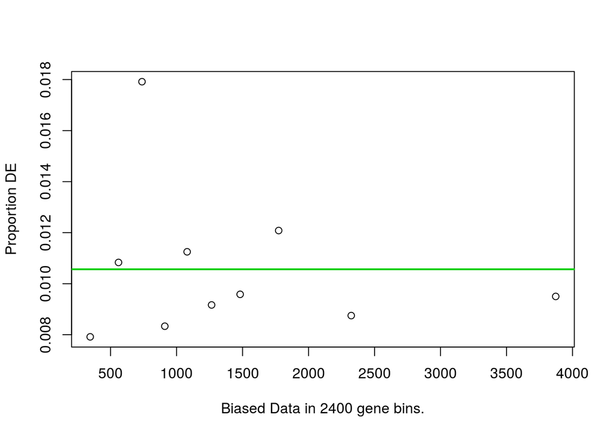

```r
#determines if there is bias due to gene length.  The plot shows the relationship.
nullp.result <- nullp(DEgenes = DE.interaction,bias.data = gene.lengths.vector)
```

```r
#calculate p-values for each GO term
rownames(nullp.result) <- names(gene.lengths.vector) #because of a bug in nullp()
GO.out <- goseq(pwf = nullp.result,gene2cat = go.list,test.cats=("GO:BP"))
```

```
## Using manually entered categories.
```

```
## For 3878 genes, we could not find any categories. These genes will be excluded.
```

```
## To force their use, please run with use_genes_without_cat=TRUE (see documentation).
```

```
## This was the default behavior for version 1.15.1 and earlier.
```

```
## Calculating the p-values...
```

```r
#list over-represented GO terms (p < 0.05)
GO.out[GO.out$over_represented_pvalue < 0.05,]
```

```
##        category over_represented_pvalue under_represented_pvalue
## 3568 GO:0043086            0.0002986779                0.9999651
## 3136 GO:0030599            0.0003253219                0.9999712
## 3601 GO:0043295            0.0009251358                0.9999624
## 57   GO:0000184            0.0028408030                0.9999419
## 181  GO:0001676            0.0036277367                0.9999135
## 3965 GO:0048046            0.0040093728                0.9985485
## 1873 GO:0009651            0.0042207146                0.9983371
## 3506 GO:0042545            0.0051007147                0.9996015
## 3704 GO:0045330            0.0051007147                0.9996015
## 1371 GO:0007047            0.0062119787                0.9991702
## 1211 GO:0006561            0.0065169210                0.9997785
## 881  GO:0005618            0.0073961722                0.9971144
## 770  GO:0004857            0.0080501464                0.9992516
## 3227 GO:0031540            0.0088646669                0.9996390
```

[output cut: 377 more lines]

```r
write.table(GO.out[GO.out$over_represented_pvalue < 0.05,1:2],row.names=FALSE,file="GO_terms.txt", quote = FALSE,col.names = FALSE)
```

**a:** In REVIGO display a “TreeMap” of the BP GO terms. Was our hypothesis that cell wall genes are enriched in the genotype X treatment gene set correct? You DO NOT need to include the treemap in your answer.

> Finding the total of percentage increase of expression in genes invovled with cell wall organization we see a 10% increase in the treatment. Our hypothesis is thus correct.

**b:** Display a “TreeMap” of the CC GO terms. There are four general categories shown, some with sub-categories. What are the two general categories with the largest number of sub categories? How might these general categories relate to differences in plant growth? You DO NOT need to include the treemap in your answer.

> The two general categories with the largest number of subcategories are endoplasmic reticulum membrane and cell wall. The plants with treatment may have increase rate of plant growth as the genes in endoplasmic reticulum membrane are overexpressed, which may have effect on protein production and other processes. The genes related to cell wall is also overexpressed, which is related to plant growth as well.

**Exercise 3** :  
Promoter motif enrichment helps us understand what causes genes to be differentially expressed. First we must get the sequence of the promoters. For ease we will define the promoters as the 1000bp upstream of the start of the gene.

To get gene “promoters”

```
extract-utr.pl --gff_file=Brapa_gene_v1.5.gff \
--genome_fa_file=BrapaV1.5_chrom_only.fa  \
--cds_fa_file=Brassica_rapa_final_CDS.fa  \
--fiveprime --utr_length=1000 --gene_length=0 \
--output_fa_file=BrapaV1.5_1000bp_upstream.fa
```

load promoter sequences

```r
library(Biostrings) #R package for handling DNA and protein data
promoters <- readDNAStringSet("./Brapa_reference/BrapaV1.5_1000bp_upstream.fa")

#convert "N" to "-" in promoters.  otherwise motifs will match strings of "N"s
promoters <- DNAStringSet(gsub("N","-",promoters))

promoters
```

```
##   A DNAStringSet instance of length 41020
##         width seq                                      names
##     [1]  1000 CTACTCAAAATAAAATAAA...GCGTTCTATTGCAGAAAC Bra000001
##     [2]  1000 TTATATATTTACACTAACA...CTAAAGTTATTATCTAAG Bra000002
##     [3]  1000 TAAAAAAATTTATGTTTTA...CTCTTGCTTTAGCTGGAT Bra000003
##     [4]  1000 TTGTGTTGTAGTTGTAGCT...TTAAGAAGCAACCTTTCG Bra000004
##     [5]  1000 CATCATCCTCTCAGATCTA...TCGGTGATCGGAGCCACG Bra000005
##     ...   ... ...
## [41016]     0                                          Bra041170
## [41017]     0                                          Bra041171
## [41018]     0                                          Bra041172
## [41019]     0                                          Bra041173
## [41020]     0                                          Bra041174
```

Load the motifs and convert to a good format for R

```r
motifs <- read.delim("./Brapa_reference/element_name_and_motif_IUPACsupp.txt",header=FALSE,as.is=TRUE)
head(motifs)
```

```
##                              V1             V2
## 1     ABFs binding site motif         CACGTGGC
## 2      ABRE binding site motif        YACGTGGC
## 3 ABRE-like binding site motif        BACGTGKM
## 4           ACE promoter motif      GACACGTAGA
## 5        AG binding site motif  TTDCCWWWWWWGGH
## 6                 AG BS in AP3     CCATTTTTAGT
```

```r
motifsV <- as.character(motifs[,2])
names(motifsV) <- motifs[,1]
motifsSS <- DNAStringSet(motifsV)
motifsSS
```

```
##   A DNAStringSet instance of length 100
##       width seq                                        names
##   [1]     8 CACGTGGC                                   ABFs binding site...
##   [2]     8 YACGTGGC                                   ABRE binding site...
##   [3]     8 BACGTGKM                                   ABRE-like binding...
##   [4]    10 GACACGTAGA                                 ACE promoter motif
##   [5]    14 TTDCCWWWWWWGGH                             AG binding site m...
##   ...   ... ...
##  [96]     5 GGGCC                                      SORLIP2
##  [97]     9 CTCAAGTGA                                  SORLIP3
##  [98]     9 GTATGATGG                                  SORLIP4
##  [99]     7 GAGTGAG                                    SORLIP5
## [100]    11 YCYAACGGYYA                                MSA
```

Next we need to subset the promoters into those in our DE genes and those in the “Univserse”

```r
#get names to match...there are are few names in the DEgene list not in the promoter set
DEgene.interaction.match <- DEgenes.gt.trt$X[DEgenes.gt.trt$X %in% names(promoters)]

#subset promoter files
universe.promoters <- promoters[expressed.genes.match]
target.promoters <- promoters[DEgene.interaction.match]
```

Look for over-represented motifs

```r
#create a function to summarize the results and test for significance
motifEnrichment <- function(target.promoters,universe.promoters,all.counts=F,motifs=motifsSS) {

  #use vcountPDict to count the occurrences of each motif in each promoter
  target.counts <- vcountPDict(motifs,target.promoters,fixed=F) +
    vcountPDict(motifsSS,reverseComplement(target.promoters),fixed=F)
  universe.counts <- vcountPDict(motifs,universe.promoters,fixed=F) +
    vcountPDict(motifsSS,reverseComplement(universe.promoters),fixed=F)

  if (all.counts) {
    #count all occurrences of a motif instead of the number of promoters that it occurs in
    target.counts.sum <- apply(target.counts,1,sum)
    universe.counts.sum <- apply(universe.counts,1,sum)
  } else {
    target.counts.sum <- apply(ifelse(target.counts > 0,1,0),1,sum)
    universe.counts.sum <- apply(ifelse(universe.counts > 0 , 1, 0),1,sum)
  }
  n.motifs <- length(target.counts.sum)
  results <- vector(mode="numeric",length=n.motifs)
  for (i in 1:n.motifs) {
    if (all.counts) { #the contigency tables are different depending on whether we are looking at promoters or overall occurrences
      #test if ratio of occurrences to promoters is the same in the target and the universe
      m <- matrix(c(
        target.counts.sum[i],                       #number of occurrences within target
        dim(target.counts)[2],                      #number of promoters in target
        universe.counts.sum[i],                  #number of occurrences within universe
        dim(universe.counts)[2]                  #number of promoters in universe
      ),ncol=2)
    } else { #looking at promoters with and without hits
      m <- matrix(c(
        target.counts.sum[i],                        #number of promoters in target with hit
        dim(target.counts)[2]-target.counts.sum[i],            #number of promoters in target with no hit
        universe.counts.sum[i],                   #number of promoters in universe with hit
        dim(universe.counts)[2]-universe.counts.sum[i]   #number of promoters in universe with no hit
      ),ncol=2)
    } #else
    results[i] <- fisher.test(m,alternative="greater")$p.value
  } #for loop
  results.table <- data.frame(
    motif=names(motifs),
    universe.percent = round(universe.counts.sum/dim(universe.counts)[2],3)*100,
    target.percent = round(target.counts.sum/dim(target.counts)[2],3)*100,
    p.value =  results)
  results.table <- results.table[order(results.table$p.value),]
  head(results.table)
}

motif.results <- motifEnrichment(target.promoters,universe.promoters)
# Show the motifs with p value less than 0.05
motif.results[motif.results[,"p.value"] < 0.05,]
```

```
##                                       motif universe.percent
## 92                                SORLREP3               8.2
## 15                ATHB1 binding site motif               1.3
## 55                   L1-box promoter motif              13.0
## 88 ATB2/AtbZIP53/AtbZIP44/GBF5 BS in ProDH              40.6
## 72                         PRHA BS in PAL1               0.0
## 20                       AtMYC2 BS in RD22              35.7
##    target.percent      p.value
## 92           16.2 3.423573e-05
## 15            3.6 5.919561e-03
## 55           18.6 7.617576e-03
## 88           47.8 1.326969e-02
## 72            0.4 2.088384e-02
## 20           42.1 2.332717e-02
```

**a.** How many motifs are enriched at P < 0.05?

**b.** What is the identity of the most significantly over-enriched promoter?

> The most significantly enriched promoter is SORLREP3

**c.** What percentage of genes in the “Universe” have this motif? What percentage in our target set?

> 8.2% of genes in the “universe” have this motif. In our target set 16.2% of the genes have this motif.

**d.** You can find information on the motifs [here](http://arabidopsis.med.ohio-state.edu/AtcisDB/bindingsites.html). Do you think that the most enriched motif represents a biologically meaningful result? Discuss why or why not.

> Identification of key promoter motifs involved in the network of light-regulated gene expression by combined analysis of genomic sequence and microarray data. The motif that is enriched is biologically meaningful as light is an important stimulus for plant growth. Plants tend to bend and grow towards the direction of light, thus this promoter may regulate genes invovled in growth and cell wall production.